# STAT 184 Homework Exercises

DataComputing Chapters 5 & 6

Yaowen Tan

## Assigned Exercises

- DC Chapter 5 Exercises：All
- DC Chapter 6 Exercises: 1-10

```r
install.packages("esquisse")
```

```
Error in install.packages : Updating loaded packages
```

```r
memory.limit(102400)
```

```
[1] 102400
```

```r
install.packages("esquisse")
```

```
Error in install.packages : Updating loaded packages
```

## Front Matter

```r
rm(list = ls())

#install.packages("esquisse")
#install.packages("tidyverse")
#library(tidyverse)
#library(esquisse)
#library(mosaicData)
#library(dcData)
```

## Chapter 5 Exercises

### Problem 5.1

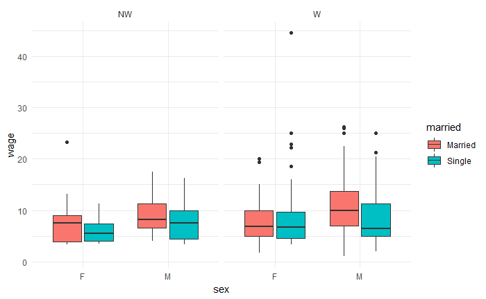

```r
data("CPS85",package = "mosaicData")
#esquisser(CPS85)
ggplot(CPS85) +
 aes(x = sex, y = wage, fill = married) +
 geom_boxplot() +
 scale_fill_hue() +
 theme_minimal() +
 facet_wrap(vars(race))
```

### Problem 5.2

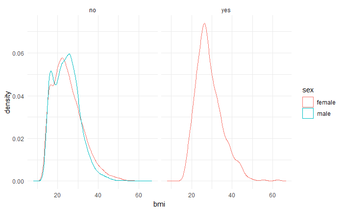

```r
data("NCHS",package = "dcData")
ggplot(NCHS) +
 aes(x = bmi, fill = followup, colour = sex) +
 geom_density(adjust = 1L) +
 scale_fill_gradient() +
 scale_color_hue() +
 theme_minimal() +
 facet_wrap(vars(pregnant))
```

```r
NA
NA
NA
```

### Problem 5.3

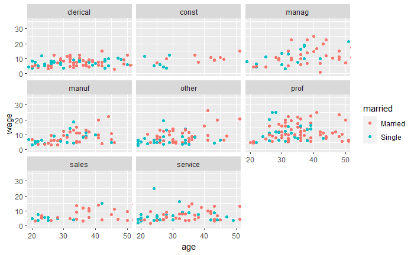

```r
data("CPS85",package = "mosaicData")
#esquisser(CPS85)
frame <- CPS85 %>%
ggplot(aes(x = age, y = wage))
frame + geom_point(aes(color = married)) + facet_wrap(~sector) + coord_cartesian(xlim = c(20, 50), ylim = c(0,35))
```

## Chapter 6 Exercises

### Problem 6.1

1. adhesion growth

2 No

3 The potision and size are suitable in each graph.

### Problem 6.2

1 y-axis interpolation show log2Enzyme, x-axis shows different kinds of Gene. Colorful dots shows that different molecule. And black dot, white dot shows that Flux is equal to 0 or greater than 0.

2 different colorful dots shows different molecule and if it’s air-corn, its Flux is greater than 0, or eqaul to 0

3 Geme amd Emzyme

4 Gene and Target

### Problem 6.3

1 Star- Signif, the value of center - polarity

2 X: Types of Protein, Y: log2 ratio low vs. high cell density

3 yes

4 the explain of the value or protein

### Problem 6.4

1 time vs The geographical position

2 different color shows different platforms, different lines shows the trains depart in different time.

3 Time, Depart time

4 under the line

### Problem 6.5

B

### Problem 6.6

D

### Problem 6.7

C

### Problem 6.8

A,B,E

### Problem 6.9

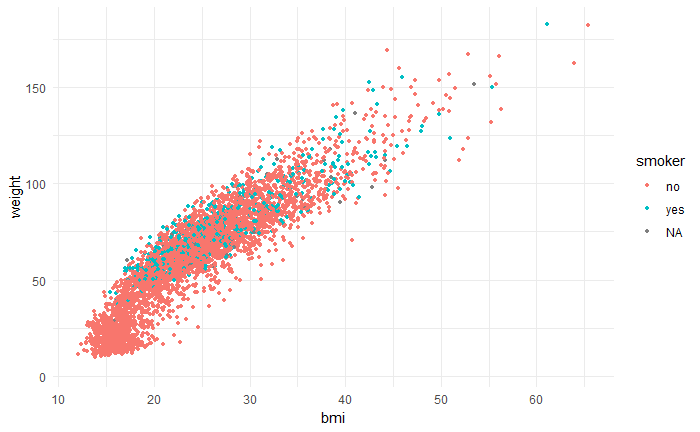

```r
small <-
  NCHS %>%
  sample_n(size=5000)
#esquisser(small)
ggplot(small) +
 aes(x = bmi, y = weight, colour = smoker) +
 geom_point(size = 1L) +
 scale_color_hue() +
 theme_minimal()
```

### Problem 6.10

1 Concentric circles

2 The type of microbial. Check them whether belong to the one Categories.